# Option Pricing: Black-Scholes vs. Monte Carlo Methods in Python

### **Stochastic Calculus prerequesite:**

Under the Black-Scholes model hypotheses, the asset prices $S_t$ follow a geometric brownian motion: $$ dS_t = \mu S_t \, dt + \sigma S_t \, dB_t $$ where $(B_t)_{t \ge 0}$ is a brownian motion, $\mu \in \mathbb{R}_{+}$ is the expected return of the investor, and $\sigma \in \mathbb{R}_{+}$ is the volatility.

> **Definition:** A Brownian motion (Wiener process) is a stochastic process $(B_t)_{t \ge 0}$ with the following properties:
> 1. $B_0=0$
> 2. Independent increments: $\forall s<t, \, B_t-B_s \perp\!\!\!\perp B_s$
> 3. Stationary Gaussian increments: $\forall s<t, \, B_t-B_s \sim \mathcal{N}(0, t-s)$

> **Itô's lemma:**

> Itô's lemma shows that a function of class $\mathcal{C}^2$ of p semimartingales whose paths are continuous is still a semimartingale.
> Let $X$ be a semimartingale whose trajectories are continuous, and $F \in \mathcal{C}^2(\mathbb{R},\mathbb{R})$.
> Almost surely, $$\forall t \ge 0, \, F(X_t) = F(X_0) + \int_{0}^{t} F'(X_s) \, dX_s + \frac{1}{2} \int_{0}^{t} F''(X_s) \, d \langle X,X \rangle _s$$
> In p dimensions, considering p semimartingales $X^{(1)}, \, X^{(2)},..., \, X^{(p)}$ whose paths are continunous, and $F \in \mathcal{C}^2(\mathbb{R}^p,\mathbb{R})$.
> Almost surely, $$\forall t \ge 0, \, F(X^{(1)}_t,..., \, X^{(p)}_t) = F(X^{(1)}_0,..., \, X^{(p)}_0) + \sum_{i=1}^{p} \int_{0}^{t} \frac{\partial F}{\partial x_i}(X^{(1)}_s,..., \, X^{(p)}_s) \, dX^{(i)}_s + \frac{1}{2} \sum_{i=1}^{p} \sum_{j=1}^{p} \int_{0}^{t} \frac{\partial^2 F}{\partial x_i x_j}(X^{(1)}_s,..., \, X^{(p)}_s) \, d \langle X^{(i)},X^{(j)} \rangle _s$$
> Itô's lemma can also be written using differentials. For $F \in \mathcal{C}^2(\mathbb{R}^2, \mathbb{R})$ applied to a stochastic process $X$ and a deterministic variable $t$: $$dF(X_t,t) = \frac{\partial F}{\partial x}(X_t,t) \, dX_t + \frac{\partial F}{\partial t}(X_t,t) \, dt + \frac{1}{2} \frac{\partial^2 F}{\partial x^2} (X_t,t) \, d \langle X,X \rangle _t $$ because $d \langle X,t \rangle = d \langle t,t \rangle = 0$ since $t$ is a bounded variation process.

Let $f$ be an option. It can be viewed as a function of $S$ and $t$, where $dS_t = \mu S_t \, dt + \sigma S_t \, dB_t$.

Using Itô's lemma, the process followed by this option is described by:

\begin{align} df &= \frac{\partial f}{\partial S}dS + \frac{\partial f}{\partial t}dt + \frac{1}{2}\frac{\partial^{2}f}{\partial S^{2}}dS^2 \\ &= \frac{\partial f}{\partial S} \left(\mu S \, dt + \sigma S \, dB_t \right) + \frac{\partial f}{\partial t}dt + \frac{1}{2}\frac{\partial^{2}f}{\partial S^{2}}\left(\mu S \, dt + \sigma S \, dB_t \right)^2 \\ &= \left( \frac{\partial f}{\partial S}\mu S + \frac{\partial f}{\partial t} + \frac{1}{2}\sigma^{2}S^{2}\frac{\partial^{2}f}{\partial S^{2}}\right)dt + \frac{\partial f}{\partial S}\sigma S \, dB_t \end{align}

The passage from $(2)$ to $(3)$ comes from the same reason as previously: $d \langle X,t \rangle = d \langle t,t \rangle = 0$, and $d \langle B,B \rangle _t = t$

### **Black-Scholes PDE derivation:**

Let us consider the portfolio $\Pi$, longing the option $V$ and shorting $\Delta$ amount of the underlying asset $S$: $$ \Pi = V - \Delta S $$ Then, the change in value of the portfolio over time is: \begin{align} d\Pi &= dV - \Delta dS \\ &= \left( \frac{\partial V}{\partial S}\mu S + \frac{\partial V}{\partial t} + \frac{1}{2}\sigma^{2}S^{2}\frac{\partial^{2}V}{\partial S^{2}}\right)dt + \frac{\partial V}{\partial S}\sigma S_t \, dB_t - \Delta \Big(\mu S_t \, dt + \sigma S_t \, dB_t \Big) \\ &= \left( \frac{\partial V}{\partial S}\mu S + \frac{\partial V}{\partial t} + \frac{1}{2}\sigma^{2}S^{2}\frac{\partial^{2}V}{\partial S^{2}} - \Delta \mu S_t \right)dt + \left( \frac{\partial V}{\partial S}\sigma S_t - \Delta \, \sigma S_t \right) dB_t \\ \end{align} We get rid of the stochastic part by setting: $$ \Delta = \frac{\partial V}{\partial S} $$ By doing so, only the deterministic part of the equation remains: $$ d\Pi = \left( \frac{\partial V}{\partial S}\mu S + \frac{\partial V}{\partial t} + \frac{1}{2}\sigma^{2}S^{2}\frac{\partial^{2}V}{\partial S^{2}} - \frac{\partial V}{\partial S} \mu S_t \right)dt $$ This eliminates risk from the portfolio, thus from the no-arbitrage hypothesis, this portfolio should yield the same amount as if placed at a risk-free rate $r$: $$ d\Pi = r \Pi dt $$ Combining these two equations, then dividing by $dt > 0$, we have: $$ \frac{\partial V}{\partial S}r S + \frac{\partial V}{\partial t} + \frac{1}{2}\sigma^{2}S^{2}\frac{\partial^{2}V}{\partial S^{2}} - \frac{\partial V}{\partial S} r S_t = r \Pi $$ By substituting $\Pi$ by its value $V - \frac{\partial V}{\partial S} S$, we derive the Black-Scholes equation: $$ \frac{\partial V}{ \partial t} + r \, S\frac{\partial V}{\partial S} +\frac{1}{2}\sigma^{2}S^{2}\frac{\partial^{2} V}{\partial S^{2}} = r\,V $$

### **Black-Scholes Call Formula:**

The solution of the Black-Scholes equation for an european call option $C(S,t)$, given the maturity $T$ and strike price $K$ is given $\forall t \in [0,T]$ by:

$$ C(S,t) = S_t \, N(d_{1}) - K\,e^{-r(T-t)}N(d_{2})\,, $$ where: $$ d_{1} = \frac{\ln(\frac{S_t}{K}) + \left(r + \frac{\sigma^{2}}{2}\right)\left(T-t\right)}{\sigma\sqrt{T-t}}\,, $$ $$ d_{2} = \frac{\ln(\frac{S_t}{K}) + \left(r - \frac{\sigma^{2}}{2}\right)\left(T-t\right)}{\sigma\sqrt{T-t}}\,, $$ and where $N(x)$ is the cumulative normal distribution of $\mathcal{N}(0,1)$: $$ N(x)= \int_{-\infty}^{x} \frac{1}{\sqrt{2\pi}} e^{-\frac{t^{2}}{2}} dt \,. $$

**Proof:**

The discounted value of a derivative is: $$ V(t) = \mathbb{E}\left[e^{- \int_{t}^{T} r(u) du} \; V(T) \Big| \mathcal{F}_t \right] $$ Under the Black-Scholes hypotheses, r is constant, and by setting $\tau = T -t$: $$ V(t) = e^{-r\tau} \; \mathbb{E} \left[V(T) \Big| \mathcal{F}_t \right] $$ On the other hand, let $S$ follow a geometric brownian motion under the real-world probability measure $\mathbb{P}$: $$ dS_t = \mu S_t dt + \sigma S_t dB^{\mathbb{P}}_t $$

By Girsanov, there's an equivalent measure $\mathbb{Q}$ (due to the no-arbitrage hypothesis), called the risk-neutral measure, where $B^{\mathbb{Q}}$ is a Brownian motion under this new measure:

Define the Radon-Nikodym derivative: $$ \frac{d\mathbb{Q}}{d\mathbb{P}} = \mathcal{E} \Bigg(- \int_0^t \theta_s dB^{\mathbb{P}}_s \Bigg) $$

where $\theta_t = \frac{\mu - r}{\sigma}$ is the market price of risk.

Then, by Girsanov's theorem, we have a new Brownian motion under $\mathbb{Q}$: $$ dB^{\mathbb{Q}}_t = dB^{\mathbb{P}}_t + \theta_t dt $$

Thus: \begin{align*} dS_t &= \mu S_t dt + \sigma S_t dB^{\mathbb{P}}_t \\ &= \mu S_t dt + \sigma S_t \bigg( dB^{\mathbb{Q}}_t - \frac{\mu - r}{\sigma} dt \bigg) \\ &= r S_t dt + \sigma S_t dB^{\mathbb{Q}}_t \end{align*}

By Itô's lemma applied to $f(S,t) = \ln S$, since $\frac{\partial f}{\partial t} = \frac{\partial^2 f}{\partial t^2} = \frac{\partial^2 f}{\partial S \partial t} = 0$: \begin{align*} df &= \frac{\partial f}{\partial S} dS + \frac{1}{2} \frac{\partial^2 f}{\partial S^2} dS^2\\ &= \frac{1}{S} dS - \frac{1}{2} \frac{1}{S^2} \sigma^2 S^2 dt \\ &= \frac{1}{S} \Big(r S dt + \sigma S dB^{\mathbb{Q}}_t \Big) - \frac{1}{2} \sigma^2 dt \end{align*}

By rearranging, we find: $$ d[ln(S)] = \left(r-\frac{\sigma^2}{2} \right)dt + \sigma dB^{\mathbb{Q}}_t $$

i.e. $$ ln(S_T) - ln(S_t) = \left(r-\frac{\sigma^2}{2} \right)d\tau + \sigma dB^{\mathbb{Q}}_{\tau} $$

Writing $B^{\mathbb{Q}}_t = \epsilon \sqrt{t}$ with $\epsilon \sim \mathcal{N}(0,1)$: $$ S_T = S_t \, e^{\left(r-\frac{\sigma^2}{2} \right)\tau + \sigma \epsilon \sqrt{\tau}} $$

For a European call, the expected payoff at maturity is: $$ V(T) = (S_T - K)^+ $$ For the call to be worthy at maturity, the following condition must be satisfied: $$ S_T > K \Rightarrow \epsilon > \frac{ln\left(\frac{K}{S_t}\right) - \left(r - \frac{\sigma^2}{2} \right) \tau}{\sigma \sqrt{\tau}} := -d_2 $$ Thus: \begin{align*} V(t) &= e^{-r\tau} \; \mathbb{E} \left[V(T) \Big| \mathcal{F}_t \right] \\ &= e^{-r\tau} \; \mathbb{E} \left[(S_T - K)^+ \Big| \mathcal{F}_t \right] \\ &= e^{-r\tau} \; \int_{-d_2}^{\infty} \left( S_t e^{\left(r-\frac{\sigma^2}{2} \right)\tau + \sigma \epsilon \sqrt{\tau}} - K \right) \frac{1}{\sqrt{2\pi}} e^{-\frac{\epsilon^{2}}{2}} d\epsilon \\ &= S_t \int_{-d_2}^{\infty} \frac{1}{\sqrt{2\pi}} e^{-\frac{\left(\sigma\sqrt{\tau}-\epsilon \right)^2}{2}} d\epsilon - K \, e^{-r\tau} \int_{-d_2}^{\infty} \frac{1}{\sqrt{2\pi}} e^{-\frac{\epsilon^{2}}{2}} d\epsilon \\ \end{align*} With a change the variable $\tilde{\epsilon} = \epsilon - \sigma \sqrt{\tau}$ and by introducing $d_1 = d_2 + \sigma \sqrt{\tau}$ \begin{align*} V(t) &= S_t \int_{-d_1}^{\infty} \frac{1}{\sqrt{2\pi}} e^{-\frac{\tilde{\epsilon}^2}{2}} d\tilde{\epsilon} - K \, e^{-r\tau} \int_{-d_2}^{\infty} \frac{1}{\sqrt{2\pi}} e^{-\frac{\epsilon^{2}}{2}} d\epsilon \\ &= S_t \left( 1-N(-d_1) \right) - K \, e^{-r\tau} \left(1-N(-d_2) \right) \\ &= S_t \, N(d_1) - K \, e^{-r\tau} N(d_2) \\ \end{align*}

## Python Implementation of Black-Scholes

```python
import numpy as np
import pandas as pd
from scipy import stats
import matplotlib.pyplot as plt
import matplotlib.ticker as ticker
import seaborn as sns
import numpy.random as npr
```

```python
def BScall(St,K,r,sigma,T,t):
    d1 = (np.log(St/K)+(r+((sigma**2)/2))*(T-t))/(sigma*np.sqrt((T-t)))
    d2 = d1-sigma*np.sqrt((T-t))
    ST = St*stats.norm.cdf(d1) - K*np.exp(-r*(T-t))*stats.norm.cdf(d2)
    return ST
```

[figure not shown]

```python
t = np.arange(0, 2.0, 0.0001) #T=2
T=2

plt.figure(figsize = (10,8))
plt.plot(t,BScall(100,95,0.06,0.3,T,t), label = 'K = 90')
plt.plot(t,BScall(100,95,0.06,0.3,T,t), label = 'K = 95')
plt.plot(t,BScall(100,98,0.06,0.3,T,t), label = 'K = 98')
plt.plot(t,BScall(100,100,0.06,0.3,T,t), label='K = 100')
plt.plot(t,BScall(100,105,0.06,0.3,T,t), label = 'K = 105')
plt.plot(t,BScall(100,105,0.06,0.3,T,t), label = 'K = 110')

plt.xlabel('t')
plt.ylabel('C')

plt.legend()
plt.show()
```

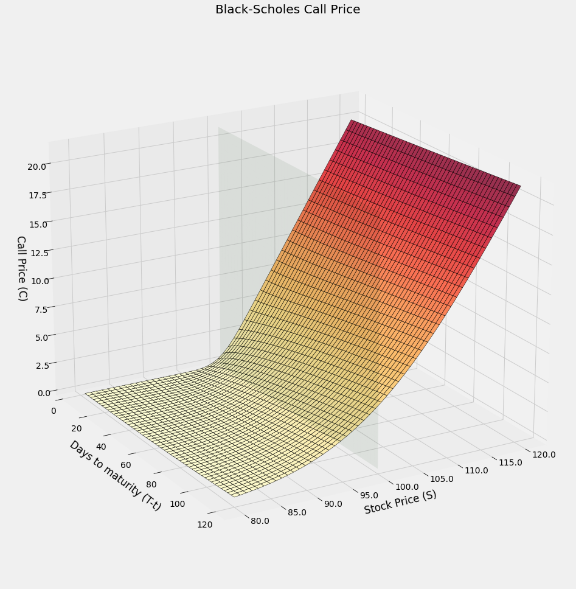

```python
# Parameters
S = 100   # Spot price
r = 0.05  # Risk-free rate
sigma = 0.2  # Volatility
T = 120/365     # Maturity time

# Grid for K and t
K_values = np.linspace(80, 120, 50)
t_values = np.linspace(0.01, T, 50)  # Avoid t = T to prevent division by zero/ # be careful in the formula we have T-t, so when t=2, time to maturity is 0
K, t = np.meshgrid(K_values, t_values) # K.shape = (len(K_values), len(t_values)) = (50,50)

# Evaluate the function
C = np.zeros_like(K)
n = K.shape[1]
for i in range(K.shape[0]):
    for j in range(K.shape[1]):
        C[i, j] = BScall(S, K[i, n-1-j], r, sigma, T, T-t[i, j])

# Plot
fig = plt.figure(figsize=(16, 16))
ax = fig.add_subplot(111, projection='3d')
surf = ax.plot_surface(K, t*365, C, cmap='YlOrRd', edgecolor='k', alpha=0.8) # k for black

# Create a plane at x = 100
x_plane = 100
Y_plane, Z_plane = np.meshgrid(t_values, np.linspace(np.min(C), np.max(C), len(t_values)))
ax.plot_surface(np.full_like(Y_plane, x_plane), Y_plane * 365, Z_plane, color='g', alpha=0.07)

# Change the angle
ax.view_init(elev=20, azim=60)

ax.set_xlabel('Stock Price (S)')
ax.set_ylabel('Days to maturity (T-t)', labelpad=10)
ax.set_zlabel('Call Price (C)', labelpad=10)
ax.set_title('Black-Scholes Call Price')

ax.invert_xaxis()  # Inverts the axis orientation

# Set the locator for the x-axis
ax.xaxis.set_major_locator(ticker.FixedLocator(ax.get_xticks()))

# change xticks position for visual purpose
ax.set_xticklabels(ax.get_xticks(), verticalalignment='bottom', horizontalalignment='left')

# Add colorbar
#fig.colorbar(surf, shrink=0.5, aspect=10, label='Call Price (C)') # shrink: changes colorbar height, aspect: height vs weight ratio
plt.show()
```

# Monte Carlo Method

The Monte Carlo method is often used to price options which are complexe (with no closed form solution) and non path-dependent. We start by taking the geometric brownian motion which the underlying stock $S(t)$ follows, in the risk-neutral measure: $$ dS_t = S_t \, r dt +S_t \, \sigma dB_t $$ This equation can be discretized by an Euler scheme. By doing this, we obtain the level of stock index $S_{T}$ at a future $T$ given a level $S_{t}$ as: $$ S_{T} = S_{t}\exp\left\{\left(r-\frac{1}{2}\sigma^{2}\right)(T-t) +\sigma \epsilon \sqrt{T-t} \right\} $$

We can simulate the process for $S_{T}$ using the Monte Carlo method. As an example, we set $r=0.06$, $\sigma = 0.3$, $T-t = 1$, $S_{t} = 100 $. We make $I = 100000$ iterations and choose $M = 100$ intervals for the time interval discretization.

```python
r=0.06
sigma = 0.3
T = 1
S0 = 100
I = 100000
M = 100
dt = T/M

S = np.zeros((M+1, I))
S[0] = S0
for t in range(1,M+1):
    S[t] = S[t-1]*np.exp((r -0.5*sigma**2)*dt +sigma*np.sqrt(dt)*npr.standard_normal(I))
```

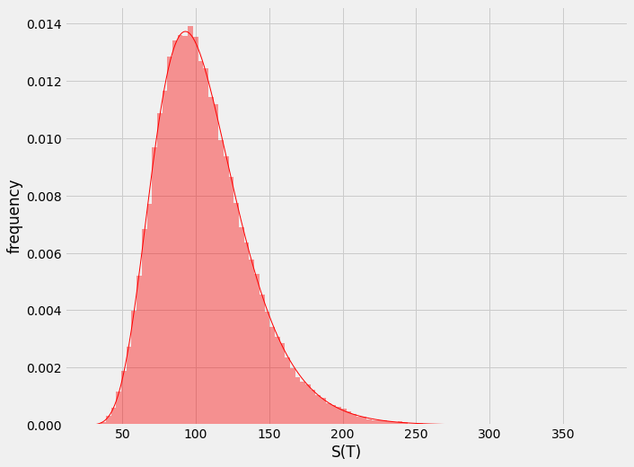

```python
# Calculate parameters for the lognormal distribution
shape, loc, scale = stats.lognorm.fit(S[-1], floc=0)  # Fit the data to a lognormal distribution

# Plot the histogram
plt.figure(figsize=(10, 8))
plt.hist(S[-1], bins=100, density=True, alpha=0.4, color='r')

# Generate a range of values to plot the lognormal distribution
x = np.linspace(min(S[-1]), max(S[-1]), 1000)
pdf = stats.lognorm.pdf(x, shape, loc, scale)

# Plot the lognormal PDF
plt.plot(x, pdf, 'r-', lw=1)

plt.xlabel('S(T)')
plt.ylabel('frequency')
plt.show()
```

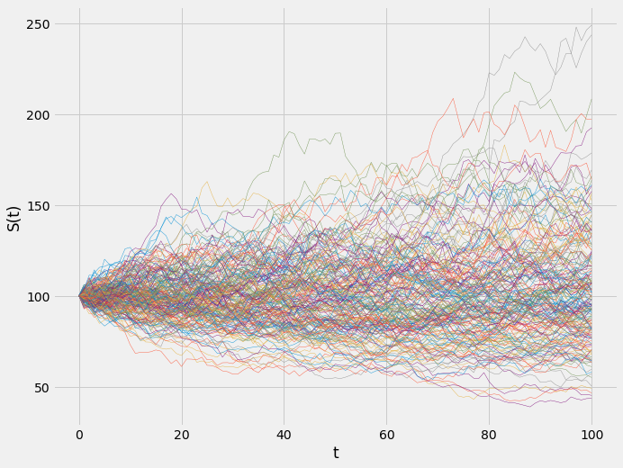

```python
plt.figure(figsize=(10, 8))
plt.plot(S[:, :200], linewidth=0.4) # M=100 on prend tous les temps, et 200 premières simulations
plt.xlabel('t')
plt.ylabel('S(t)')
plt.show()
```

We know that, in the case of a call option, the payoff function at maturity $T$ is given by: $$\ h(S_{T}) = \max \left( S_{T}-K,0\right)\,. $$ Then, in the particular case of a risk-free setting, it can be shown that the call option price is given by: $$ C(T) = e^{-r(T-t)}\int_{-\infty}^{\infty}\,h(S_{T})\,q(S_{T})\,dS_{T}, $$ where $q(S)$ is a probability density for the equivalent martingale process to $S_{t}$. This integral can actually be discretized, yielding: $$ C(T) = e^{-r(T-t)}\frac{1}{I}\sum_{i = 1}^{I}h(S_{T}^{i})\,, $$ where the sum is taken over a collection $S_{T}^{i}$ following a geometric brownian motion that can be generated by Monte Carlo simulation.

```python
def MCcall(S,K,r,sigma,T,t,I):

    data = np.zeros((I, 2)) # 1st column will be kept 0, so that each line is [0, ST-K]

    z = np.random.normal(0, 1, [1, I])

    #z = npr.standard_normal(I)

    ST = S*np.exp((T-t)*(r - 0.5*sigma**2)+sigma*np.sqrt(T-t)*z) # z is not a vector so no transposition required

    data[:,1] = ST - K

    average = np.sum(np.max(data, axis=1))/float(I)

    return np.exp(-r*(T-t))*average
```

We compare the Monte Carlo result for various values and see that there is good agreement:

```python
print('Monte Carlo:',MCcall(100,95,0.06,0.3,1,.999,100000))
print('Exact: ',BScall(100,95,0.06,0.3,1,.999))
```

```
Monte Carlo: 5.007651528077432
Exact:  5.005699833982007
```

```python
print('Monte Carlo:',MCcall(100,95,0.06,0.3,1,.75,100000))
print('Exact: ',BScall(100,95,0.06,0.3,1,.75))
```

```
Monte Carlo: 9.531971735788114
Exact:  9.548802012535894
```

We can plot how the value of the Monte Carlo call option converges to the exact value as the number of iterations increases:

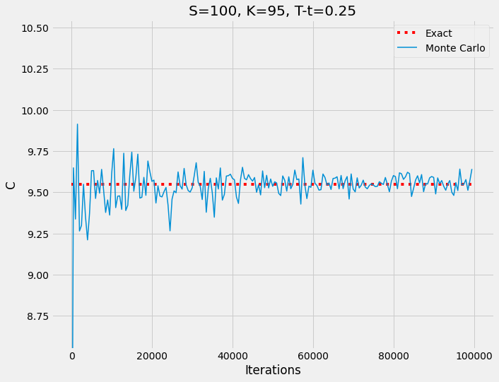

```python
df = pd.DataFrame(columns=['Iter','BSc'])

for i in range(1, 100000, 500):
    new_row = pd.DataFrame({'Iter': [i], 'BSc': [MCcall(100, 95, 0.06, 0.3, 1, 0.75, i)]})
    df = pd.concat([df, new_row], ignore_index=True)

plt.figure(figsize=(10,8))

plt.hlines(BScall(100,95,0.06,0.3,1,0.75),xmin=0,xmax= 100000,linestyle='dotted',colors='red',label = 'Exact')
plt.plot(df.set_index('Iter'),lw = 1.5, label = 'Monte Carlo')

plt.title('S=100, K=95, T-t=0.25')
plt.xlabel('Iterations')
plt.ylabel('C')
plt.ylim(BScall(100,95,0.06,0.3,1,0.75)-1,BScall(100,95,0.06,0.3,1,0.75)+1)
plt.legend()
plt.show()
```

[figure not shown]

```python
df = pd.DataFrame(columns=['Iter','BSc'])

for i in range(1, 100000, 500):
    new_row = pd.DataFrame({'Iter': [i], 'BSc': [MCcall(100, 95, 0.06, 0.3, 1, 0.99, i)]})
    df = pd.concat([df, new_row], ignore_index=True)

plt.figure(figsize=(10,8))

plt.plot(df.set_index('Iter'),lw = 1.5)
plt.hlines(BScall(100,95,0.06,0.3,1,0.99),xmin=0,xmax= 100000,linestyle='dotted',colors='red')

plt.title('S=100, K=95, T-t=0.001')
plt.xlabel('Iterations')
plt.ylabel('C')
plt.ylim(BScall(100,95,0.06,0.3,1,0.99)-1,BScall(100,95,0.06,0.3,1,0.99)+1)

plt.show()
```

Finally, we plot the Monte Carlo call option as a function of time and compare it with the exact result, for the values $S =100$ and $K =95,\,98,\,100,\,105$.

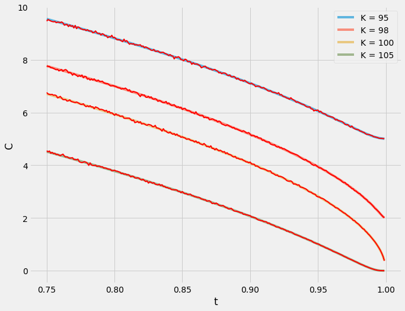

```python
df = pd.DataFrame(columns=['t','95','98','100','105'])
t = np.arange(0.75, 1.0, 0.001)

for i in t:
    new_row = pd.DataFrame({'t': [i], '95': MCcall(100,95,0.06,0.3,1,i,100000),'98': MCcall(100,98,0.06,0.3,1,i,100000),'100': MCcall(100,100,0.06,0.3,1,i,100000),'105': MCcall(100,105,0.06,0.3,1,i,100000)})
    df = pd.concat([df, new_row], ignore_index=True)

plt.figure(figsize=(10,8))
plt.plot(t,BScall(100,95,0.06,0.3,1,t),alpha=0.6, label = 'K = 95')
plt.plot(t,BScall(100,98,0.06,0.3,1,t),alpha=0.6, label = 'K = 98')
plt.plot(t,BScall(100,100,0.06,0.3,1,t),alpha=0.6, label = 'K = 100')
plt.plot(t,BScall(100,105,0.06,0.3,1,t),alpha=0.6, label = 'K = 105')

plt.plot(df['t'],df['95'],lw=2,c='r')
plt.plot(df['t'],df['98'],lw=2,c='r')
plt.plot(df['t'],df['100'],lw=2,c='r')
plt.plot(df['t'],df['105'],lw=2,c='r')

plt.legend()
plt.xlabel('t')
plt.ylabel('C')

plt.show()
```